# Week 10 Assignment – Sentiment Analysis

Ellen Kim

2020-10-31

```r
library(tidyverse)
library(openintro)
library(dplyr)
library(tidytext)
library(textdata)
library(tidyr)
library(janeaustenr)
library(ggplot2)
library(stringr)
```

### Re-create base analysis

```r
get_sentiments("afinn")
```

```
## # A tibble: 2,477 x 2
##    word       value
##    <chr>      <dbl>
##  1 abandon       -2
##  2 abandoned     -2
##  3 abandons      -2
##  4 abducted      -2
##  5 abduction     -2
##  6 abductions    -2
##  7 abhor         -3
##  8 abhorred      -3
##  9 abhorrent     -3
## 10 abhors        -3
## # … with 2,467 more rows
```

```r
get_sentiments("bing")
```

```
## # A tibble: 6,786 x 2
##    word        sentiment
##    <chr>       <chr>
##  1 2-faces     negative
##  2 abnormal    negative
##  3 abolish     negative
##  4 abominable  negative
##  5 abominably  negative
##  6 abominate   negative
##  7 abomination negative
##  8 abort       negative
##  9 aborted     negative
## 10 aborts      negative
## # … with 6,776 more rows
```

```r
get_sentiments("nrc")
```

```
## # A tibble: 13,901 x 2
##    word        sentiment
##    <chr>       <chr>
##  1 abacus      trust
##  2 abandon     fear
##  3 abandon     negative
##  4 abandon     sadness
##  5 abandoned   anger
##  6 abandoned   fear
##  7 abandoned   negative
##  8 abandoned   sadness
##  9 abandonment anger
## 10 abandonment fear
## # … with 13,891 more rows
```

```r
# tokenize lines to words
tidy_books <- austen_books() %>%
  group_by(book) %>%
  mutate(
    linenumber = row_number(),
    chapter = cumsum(str_detect(text, regex("^chapter [\\divxlc]",
      ignore_case = TRUE
    )))
  ) %>%
  ungroup() %>%
  unnest_tokens(word, text)

# get joy words from nrc
nrc_joy <- get_sentiments("nrc") %>%
  filter(sentiment == "joy")

# inner join "joy' sentiment words from Emma
tidy_books %>%
  filter(book == "Emma") %>%
  inner_join(nrc_joy) %>%
  count(word, sort = TRUE)
```

```
## # A tibble: 303 x 2
##    word        n
##    <chr>   <int>
##  1 good      359
##  2 young     192
##  3 friend    166
##  4 hope      143
##  5 happy     125
##  6 love      117
##  7 deal       92
##  8 found      92
##  9 present    89
## 10 kind       82
## # … with 293 more rows
```

```r
# for every chunk of 80 lines, sentiment = pos - negative
jane_austen_sentiment <- tidy_books %>%
  inner_join(get_sentiments("bing")) %>%
  # breaking lines of a book into chunks of 80
  count(book, index = linenumber %/% 80, sentiment) %>%
  # transposing sentiment values as columns
  spread(sentiment, n, fill = 0) %>%
  mutate(sentiment = positive - negative)
```

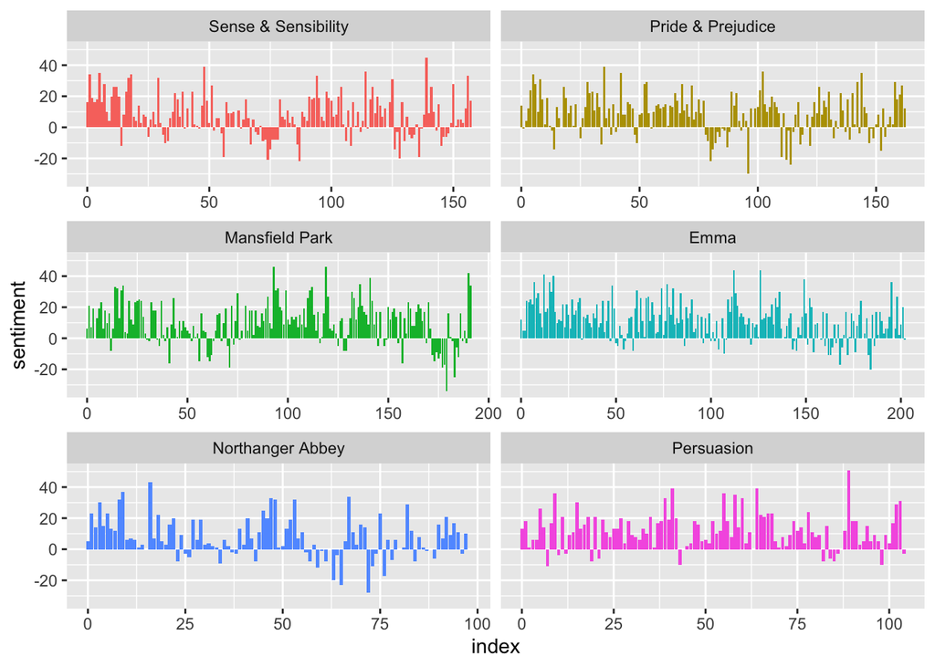

```r
ggplot(jane_austen_sentiment, aes(index, sentiment, fill = book)) +
  geom_col(show.legend = FALSE) +
  facet_wrap(~book, ncol = 2, scales = "free_x")
```

```r
# 2.3 Comparing the three sentiment dictionaries

library(tidyr)

pride_prejudice <- tidy_books %>%
  filter(book == "Pride & Prejudice")

# sentiment by 80 line chunks using AFINN
afinn <- pride_prejudice %>%
  inner_join(get_sentiments("afinn")) %>%
  group_by(index = linenumber %/% 80) %>%
  summarise(sentiment = sum(value)) %>%
  mutate(method = "AFINN")
# stack after getting sentiments of 2 diff lexicon dictionaries
# then calculate sentiment, partitioned by every 80 lines
bing_and_nrc <- bind_rows(
  # get sentiment for bing
  pride_prejudice %>%
    inner_join(get_sentiments("bing")) %>%
    mutate(method = "Bing et al."),
  # get sentiment for nrc
  pride_prejudice %>%
    inner_join(get_sentiments("nrc") %>%
      filter(sentiment %in% c(
        "positive",
        "negative"
      ))) %>%
    mutate(method = "NRC")
) %>%
  count(method, index = linenumber %/% 80, sentiment) %>%
  spread(sentiment, n, fill = 0) %>%
  mutate(sentiment = positive - negative)
```

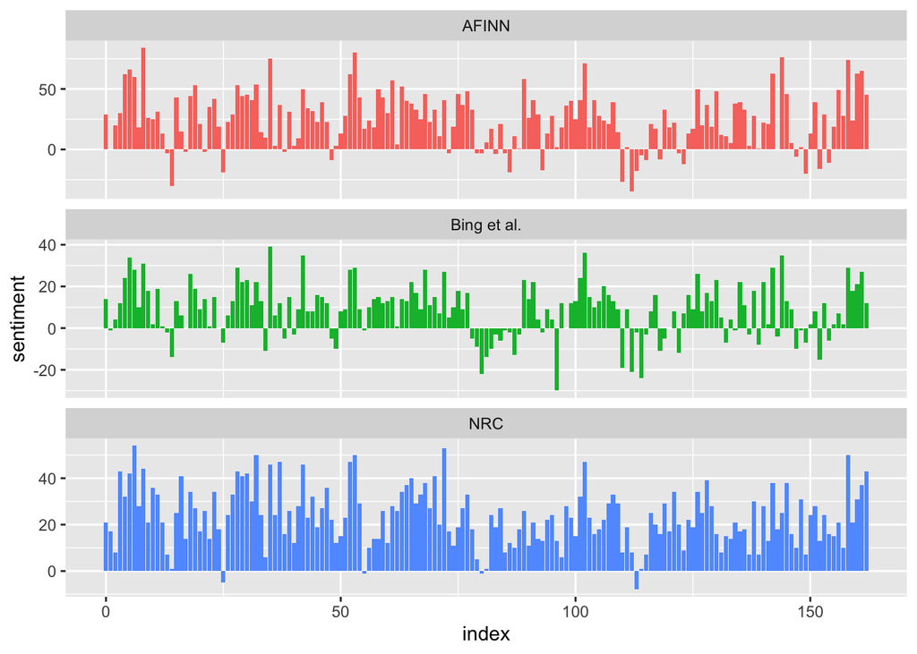

```r
# stack 3rd lexicon library AFINN and plot
bind_rows(
  afinn,
  bing_and_nrc
) %>%
  ggplot(aes(index, sentiment, fill = method)) +
  geom_col(show.legend = FALSE) +
  facet_wrap(~method, ncol = 1, scales = "free_y")
```

```r
get_sentiments("nrc") %>%
  filter(sentiment %in% c(
    "positive",
    "negative"
  )) %>%
  count(sentiment)
```

```
## # A tibble: 2 x 2
##   sentiment     n
##   <chr>     <int>
## 1 negative   3324
## 2 positive   2312
```

```r
get_sentiments("bing") %>%
  count(sentiment)
```

```
## # A tibble: 2 x 2
##   sentiment     n
##   <chr>     <int>
## 1 negative   4781
## 2 positive   2005
```

```r
#2.4 Most common positive and negative words

bing_word_counts <- tidy_books %>%
  inner_join(get_sentiments("bing")) %>%
  count(word, sentiment, sort = TRUE) %>%
  ungroup()
# most common words
bing_word_counts
```

```
## # A tibble: 2,585 x 3
##    word     sentiment     n
##    <chr>    <chr>     <int>
##  1 miss     negative   1855
##  2 well     positive   1523
##  3 good     positive   1380
##  4 great    positive    981
##  5 like     positive    725
##  6 better   positive    639
##  7 enough   positive    613
##  8 happy    positive    534
##  9 love     positive    495
## 10 pleasure positive    462
## # … with 2,575 more rows
```

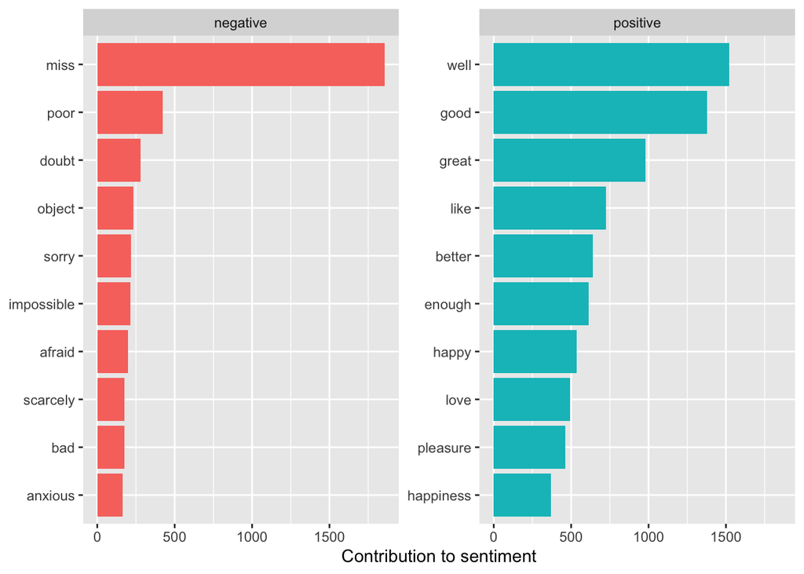

```r
bing_word_counts %>%
  group_by(sentiment) %>%
  top_n(10) %>%
  ungroup() %>%
  mutate(word = reorder(word, n)) %>%
  ggplot(aes(word, n, fill = sentiment)) +
  geom_col(show.legend = FALSE) +
  facet_wrap(~sentiment, scales = "free_y") +
  labs(
    y = "Contribution to sentiment",
    x = NULL
  ) +
  coord_flip()
```

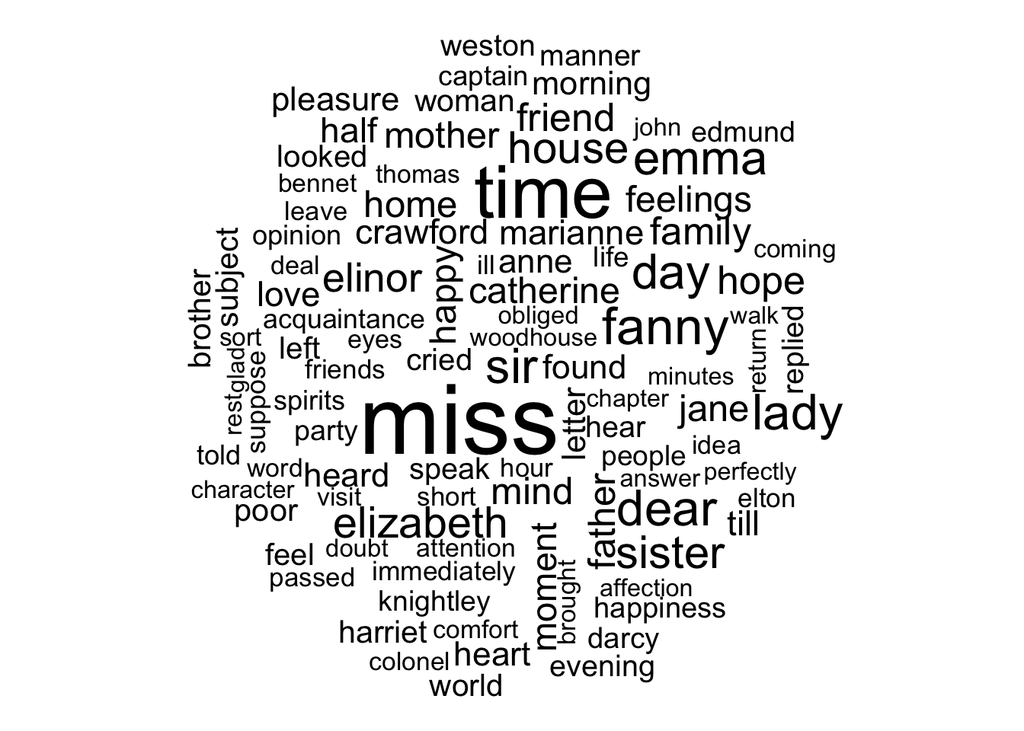

```r
# creating custom stop words list by appending to stop_words
custom_stop_words <- bind_rows(
  tibble(
    word = c("miss"),
    lexicon = c("custom")
  ),
  stop_words
)

library(wordcloud)
tidy_books %>%
  anti_join(stop_words) %>%
  count(word) %>%
  with(wordcloud(word, n, max.words = 100))
```

```r
library(reshape2)
```

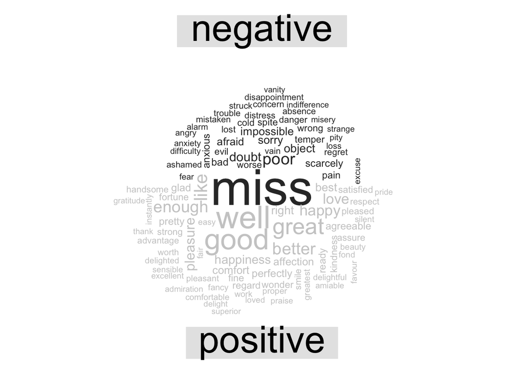

```r
tidy_books %>%
  inner_join(get_sentiments("bing")) %>%
  count(word, sentiment, sort = TRUE) %>%
  acast(word ~ sentiment, value.var = "n", fill = 0) %>%
  comparison.cloud(
    colors = c("gray20", "gray80"),
    max.words = 100
  )
```

```r
# partitioned by sentence. delimter is period.
PandP_sentences <- tibble(text = prideprejudice) %>%
  unnest_tokens(sentence, text, token = "sentences")

austen_chapters <- austen_books() %>%
  group_by(book) %>%
  unnest_tokens(chapter, text,
    token = "regex",
    pattern = "Chapter|CHAPTER [\\dIVXLC]"
  ) %>%
  ungroup()

austen_chapters %>%
  group_by(book) %>%
  summarise(chapters = n())
```

```
## # A tibble: 6 x 2
##   book                chapters
##   <fct>                  <int>
## 1 Sense & Sensibility       51
## 2 Pride & Prejudice         62
## 3 Mansfield Park            49
## 4 Emma                      56
## 5 Northanger Abbey          32
## 6 Persuasion                25
```

```r
bingnegative <- get_sentiments("bing") %>%
  filter(sentiment == "negative")

wordcounts <- tidy_books %>%
  group_by(book, chapter) %>%
  summarize(words = n())
tidy_books %>%
  semi_join(bingnegative) %>%
  group_by(book, chapter) %>%
  summarize(negativewords = n()) %>%
  left_join(wordcounts, by = c("book", "chapter")) %>%
  mutate(ratio = negativewords / words) %>%
  filter(chapter != 0) %>%
  top_n(1) %>%
  ungroup()
```

```
## # A tibble: 6 x 5
##   book                chapter negativewords words  ratio
##   <fct>                 <int>         <int> <int>  <dbl>
## 1 Sense & Sensibility      43           161  3405 0.0473
## 2 Pride & Prejudice        34           111  2104 0.0528
## 3 Mansfield Park           46           173  3685 0.0469
## 4 Emma                     15           151  3340 0.0452
## 5 Northanger Abbey         21           149  2982 0.0500
## 6 Persuasion                4            62  1807 0.0343
```

### My Corpus

My corporus is a dataset which has reviews for gourmet foods sold on Amazon. I would like to compare the sentiment analysis results with the stars given for each product.

```r
library(readr)

# file is too large. won't upload to git with free account
food_reviews <- read_csv(file= "Reviews.csv")
# data is taking too long to render
# Lets partition the data by random sampling

## 75% of the sample size
smp_size <- floor(0.50 * nrow(food_reviews))

## set the seed to make your partition reproducible
set.seed(123)
train_ind <- sample(seq_len(nrow(food_reviews)), size = smp_size)

# creates smaller set but also create identity column
train <- food_reviews[train_ind, ]
#test <- food_reviews[-train_ind, ]


tidy_reviews <- train %>%
  select(Id, ProductId, UserId, Score, Text) %>%
    unnest_tokens(word, Text) %>%
    anti_join(stop_words)
tidy_reviews_bing <- tidy_reviews %>%
  inner_join(get_sentiments("bing")) %>%
    count(ProductId, Id, sentiment, Score) %>%
      spread(sentiment, n, fill=0) %>%
      mutate(sentiment = positive - negative)
tidy_reviews_bing %>%
  group_by(Score) %>%
    summarize(avg_score = mean(sentiment))
```

```
## # A tibble: 5 x 2
##   Score avg_score
##   <dbl>     <dbl>
## 1     1    -1.40
## 2     2    -0.385
## 3     3     0.484
## 4     4     1.35
## 5     5     1.78
```

### Conclusion

We can see that the average score from the sentiment scoring is aligned with the score given by the reviewer. While the amazon reviews are on a scale of 1 to 5, the sentment count is not bound by the same scale. However, the average sentiment score is relative and does show that the lowest scored items (equal to 1) also has the lowest sentiment score, while the highest review score of 5, also has the highest sentiment scoring.

### A Different Lexicon

Previously we were using the Bing lexicon. Lets see if the “AFINN” lexicon gives us significantly different results. Methodology: Using tokenized dataframe, inner join with afinn lexicon. This lexicon outputs values from -5 to 5. The count by ProductId, Id, and Score, which results in a frequency for each sentiment value that occurs for one review. Next, create new feature called sent_times_n, which creates a score that takes frequency of each sentiment value into account. The final sentiment score, is the average score for a single review.

```r
tidy_reviews_afinn <- tidy_reviews %>%
  inner_join(get_sentiments("afinn")) %>%
    count(ProductId, Id, value, Score) %>%
      mutate(sent_times_n = value * n) %>%
      group_by(ProductId, Id,  Score) %>%
      mutate(sentiment_score = mean(sent_times_n)) %>%
      ungroup()
tidy_reviews_afinn %>%
  group_by(Score) %>%
    summarize(avg_score = mean(sentiment_score))
```

```
## # A tibble: 5 x 2
##   Score avg_score
##   <dbl>     <dbl>
## 1     1    -0.410
## 2     2     0.402
## 3     3     0.984
## 4     4     1.62
## 5     5     2.04
```

#### Findings of Second Lexicon

The use of different lexicon again, align with the ratings, as well as the conclusions of the first lexicon. Relative to each other, the lowest rated items have the lowest sentiment score and the highest rated items have the highest sentiment scores. Because my analysis had was based on relativity, it doesn’t make a signficant difference in which lexicon is used.